# Visualization (Data Transformation)

Peter Ganong and Maggie Shi

January 21, 2026

# Introduction

## Introduction: roadmap

- Putting this lecture in context
- Introducing the `movies` dataset
  - load data
  - `shape`
  - `head()`

## Putting this lecture in context

- This lecture explores methods for *transforming* data, focusing on aggregation.
  - We will be mostly following Chapter 3 in the data visualization (Heer et al.) book
- Fundamental problem in data visualization: in most cases, you **do not want to show every single data point** in your dataset.
- Instead, you want to extract patterns which you (the analyst) think are interesting.

## Aggregation

- One nice thing about `altair` is that it nudges you to aggregate.
- One example: if you try to make a plot with 10,000 dots, it will give you an error: `MaxRowsError: The number of rows in your dataset is greater than the maximum allowed (5000).`
  - Help file: “This is not because Altair cannot handle larger datasets, but it is because it is important for the user to think carefully about how large datasets are handled.”
  - More details [here](https://altair-viz.github.io/user_guide/large_datasets.html)

## Load packages and data

```python
import pandas as pd
import altair as alt

movies_url = 'https://cdn.jsdelivr.net/npm/vega-datasets@1/data/movies.json'
```

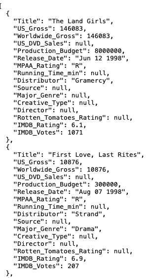

## *An aside on JSON*

- All the sample `vega-datasets` are stored as `.json`, including movies
- Other places you have or will see JSON
  - Recall from viz lecture 1 that `altair` writes Vega-lite, which is also recorded in JSON
  - In spatial lectures, we will also encounter the `geojson` format, which can store geographic features
- JSON shines at storing hierarchical data in a way that is easily readable to both humans and machines. Family tree [example](https://stackoverflow.com/questions/5129890/represent-hierarchy-in-a-json-object), wikipedia [example](https://en.wikipedia.org/wiki/JSON#Syntax).
- The movies dataset, however, is just a boring table like any other. We will convert it to `pandas` for Altair to use

```python
movies = pd.read_json(movies_url)
```

## `head()`

```python
movies.head(5)
```

|  | Title | US_Gross | Worldwide_Gross | US_DVD_Sales | Production_Budget | Release_Date | MPAA_Rating | Running_Time_min | Distributor | Source | Major_Genre | Creative_Type | Director | Rotten_Tomatoes_Rating | IMDB_Rating | IMDB_Votes |
| --- | --- | --- | --- | --- | --- | --- | --- | --- | --- | --- | --- | --- | --- | --- | --- | --- |
| 0 | The Land Girls | 146083.0 | 146083.0 | NaN | 8000000.0 | Jun 12 1998 | R | NaN | Gramercy | None | None | None | None | NaN | 6.1 | 1071.0 |
| 1 | First Love, Last Rites | 10876.0 | 10876.0 | NaN | 300000.0 | Aug 07 1998 | R | NaN | Strand | None | Drama | None | None | NaN | 6.9 | 207.0 |
| 2 | I Married a Strange Person | 203134.0 | 203134.0 | NaN | 250000.0 | Aug 28 1998 | None | NaN | Lionsgate | None | Comedy | None | None | NaN | 6.8 | 865.0 |
| 3 | Let's Talk About Sex | 373615.0 | 373615.0 | NaN | 300000.0 | Sep 11 1998 | None | NaN | Fine Line | None | Comedy | None | None | 13.0 | NaN | NaN |
| 4 | Slam | 1009819.0 | 1087521.0 | NaN | 1000000.0 | Oct 09 1998 | R | NaN | Trimark | Original Screenplay | Drama | Contemporary Fiction | None | 62.0 | 3.4 | 165.0 |

## `shape`

```python
movies.shape
```

```
(3201, 16)
```

- With 3201 movies, we are under the 5000 obs limit from `altair`.
- However, as you will see soon, it’s hard to learn much from a plot with 3201 observations.
- This is why this is a good case study for the value of transformations if we want to uncover any patterns in the data

## Variables of interest

- **Rotten Tomatoes** ratings are determined by taking “thumbs up” and “thumbs down” judgments from film critics and calculating the percentage of positive reviews.
- **IMDB ratings** are formed by averaging scores (ranging from 1 to 10) provided by the site’s users.

## Exploring the raw data

```python
alt.Chart(movies_url).mark_circle().encode(
    alt.X('Rotten_Tomatoes_Rating:Q', title = "Rotten Tomatoes Rating (%)"),
    alt.Y('IMDB_Rating:Q', title = "IMDB Rating")
)
```

[interactive chart not shown]

Recall from last lecture: label when scale is %!

# Aggregation

## Aggregation: roadmap

In previous lectures, we actually already saw aggregation via `average()` and `min()`. We just didn’t talk explicitly about that step. Now, we examine it more carefully.

- `average()`
- interquartile range
- do-pair-share

The Altair documentation includes the [full set of available aggregation functions](https://altair-viz.github.io/user_guide/encodings/index.html#aggregation-functions).

## `average()`

```python
movies = movies.dropna(subset=['Major_Genre'])
alt.Chart(movies).mark_bar().encode(
    alt.X('average(Rotten_Tomatoes_Rating):Q', title = "Average Rotten Tomatoes Rating (%)"),
    alt.Y('Major_Genre:N', title = "Genre")
)
```

[interactive chart not shown]

This plot is fine, but hard to interpret takeaways quickly.

## `average()` with `sort(...)`

More useful: sort the bars vertically, based on x-axis encoding

```python
alt.Chart(movies).mark_bar().encode(
    alt.X('average(Rotten_Tomatoes_Rating):Q', title = "Average Rotten Tomatoes Rating (%)"),
    alt.Y('Major_Genre:N', title = "Genre",
        sort=alt.EncodingSortField(op='average', field='Rotten_Tomatoes_Rating', order='descending')
    )
)
```

[interactive chart not shown]

This focuses the viewer’s attention on which movie types are most and least popular

## Interquartile range

Plot 1st and 3rd quartiles, then sort by median.

```python
alt.Chart(movies).mark_bar().encode(
    alt.X('q1(Rotten_Tomatoes_Rating):Q', title = "Rotten Tomatoes Rating (%)"),
    alt.X2('q3(Rotten_Tomatoes_Rating):Q'),
    alt.Y('Major_Genre:N', sort=alt.EncodingSortField(op='median', field='Rotten_Tomatoes_Rating', order='descending'),
        title = "Genre"
    )
)
```

[interactive chart not shown]

Discussion question: what can you learn from the IQR plot that you could not learn from the plot with just `average()`?

## Aggregation functions

- Distribution: `min()`, `q1()`, `median()`, `mean()`, `q3()`, `max()`
- Full list [here](https://altair-viz.github.io/user_guide/encodings/index.html#aggregation-functions)

## Case study: when are the highest grossing films released?

```python
movies_gross = movies[['US_Gross', 'Release_Date']]
movies_gross.head()
```

|  | US_Gross | Release_Date |
| --- | --- | --- |
| 1 | 10876.0 | Aug 07 1998 |
| 2 | 203134.0 | Aug 28 1998 |
| 3 | 373615.0 | Sep 11 1998 |
| 4 | 1009819.0 | Oct 09 1998 |
| 7 | 6026908.0 | Apr 09 1999 |

## A first pass

```python
alt.Chart(movies).mark_point().encode(
    alt.X('Release_Date:T', title = "Release Date"),
    alt.Y('US_Gross:Q', title = "US Gross ($)")
)
```

[interactive chart not shown]

Obviously we need to aggregate.

Also: what bug in the data does this plot reveal?

## Do-pair-share

1. *Do* – make a plot on your own
2. *Pair* – compare your results with person next to you
3. *Share* – discuss results as a class
- **Question**: What time of year are the highest grossing films released? Aggregate both the x- and the y-variables.
- There are several ways to approach answering this question. What seems most reasonable to you?

## Data aggregation: Do-pair-share

Starter code in lecture `dps_highest_grossing_film.qmd` file:

```python
import pandas as pd
import altair as alt
movies_url = 'https://cdn.jsdelivr.net/npm/vega-datasets@1/data/movies.json'
movies = pd.read_json(movies_url)

# unaggregated scatter plot
alt.Chart(movies).mark_point().encode(
    alt.X('Release_Date:T', title = "Release Date"),
    alt.Y('US_Gross:Q', title = "US Gross ($)")
)
```

Documentation on working with time units [here](https://altair-viz.github.io/user_guide/transform/timeunit.html)

## More on time units

`T`emporal variables can be transformed into a variety of other time units

- `year()`
- `quarter()`
- `month()`
- `date()` (numeric day in month)
- `day()` (day of the week)
- `hours()`
- `yearmonth()`
- `hoursminutes()`

## Aggregation: summary

- Many built-in aggregation functions to quantify distribution, dispersion, and characterize data
- Dates: see prior slide

# Advanced data transformation

## Advanced data transformation: introduction

- Two ways to aggregate data in `altair`
  - Within the encoding itself: `alt.Y('median(US_Gross):Q')`
  - **Separately using a top-level aggregate transform**
- Doing it in the encoding is fine for simple transformations
- But for advanced transformations, we’ll have to define it separately

## Advanced data transformation: roadmap

- `transform_calculate()`
- `transform_filter()`
- do-pair-share
- `transform_aggregate()`
- `transform_window()`

These are all written in the [Vega expression language](https://vega.github.io/vega/docs/expressions/).

## Connection to `pandas` operations

One way to think of these verbs is that they are fundamental to any data analysis project and so in any/every package you learn, you need to know how to do these.

| Purpose | Vega | `pandas` equivalent |
| --- | --- | --- |
| Define a new variable | `transform_calculate()` | `df['new_col']` |
| Filter to subset of rows | `transform_filter(cond)` | `df.loc[cond]` |
| Aggregate function - collapse number of rows down to one per group | `transform_aggregate(groupby(...))` | `df.groupby('A').agg('mean')` |
| Window function - transform across multiple rows, keeps same num. of rows) | `transform_window(sum())` | `df['values'].cumsum()` |

## Connection to `pandas` operations

- You already know how to do these all in `pandas` so it is not conceptually new.
- Why bother doing it in `altair`?
  - **Exploratory data analysis** can be done faster in `altair`: manipulate data and plot simultaneously
  - Aggregation and transformations are **temporary** – don’t need to define and keep track of new aggregated dataframes

## `transform_calculate` and `transform_timeunit`

- `transform_calculate()` uses [expressions](https://vega.github.io/vega/docs/expressions/) for writing basic formulas
  - Math functions: `min()`, `random()`, `round()`
  - Statistical functions: `sampleNormal()`, `sampleUniform()`
  - String functions: `length()`, `lower()`, `substring()`
- Use `transform_timeunit()` when working with `T`emporal variables
  - `month()`, `quarter()`, `yearmonth()`

## `transform_calculate` case study

**Question**: what time of year do US movies make money abroad?

```python
alt.Chart(movies).mark_area().transform_calculate(
    NonUS_Gross='datum.Worldwide_Gross - datum.US_Gross'
).encode(
    alt.X('month(Release_Date):T', title = "Release Month"),
    alt.Y('median(NonUS_Gross):Q', title = "Median Non-US Gross ($)")
)
```

## `transform_calculate` case study

**Question**: what time of year do US movies make money abroad?

```python
alt.Chart(movies).mark_area().transform_calculate(
    NonUS_Gross='datum.Worldwide_Gross - datum.US_Gross'
).encode(
    alt.X('month(Release_Date):T', title = "Release Month"),
    alt.Y('median(NonUS_Gross):Q', title = "Median Non-US Gross ($)")
)
```

- `NonUS_Gross` is a variable we’re defining *temporarily*

## `transform_calculate` case study

**Question**: what time of year do US movies make money abroad?

```python
alt.Chart(movies).mark_area().transform_calculate(
    NonUS_Gross='datum.Worldwide_Gross - datum.US_Gross'
).encode(
    alt.X('month(Release_Date):T', title = "Release Month"),
    alt.Y('median(NonUS_Gross):Q', title = "Median Non-US Gross ($)")
)
```

- `datum` is how you reference the underlying dataset within a transformation expression
- Here, `datum` means `movies`

## `transform_calculate` case study

**Question**: what time of year do US movies make money abroad?

```python
alt.Chart(movies).mark_area().transform_calculate(
    NonUS_Gross='datum.Worldwide_Gross - datum.US_Gross'
).encode(
    alt.X('month(Release_Date):T', title = "Release Month"),
    alt.Y('median(NonUS_Gross):Q', title = "Median Non-US Gross ($)")
)
```

- After defining `NonUS_Gross`, we can use like any other variable within `movies`
- It can be combined with other aggregation methods

## `transform_calculate` case study

**Question**: what time of year do US movies make money abroad?

[interactive chart not shown]

## `transform_filter`

- Goal: show just movies before 1970

```python
alt.Chart(movies).mark_circle().transform_filter(
    'year(datum.Release_Date) < 1970').encode(
    alt.X('Rotten_Tomatoes_Rating:Q', title = "Rotten Tomatoes Rating (%)"),
    alt.Y('IMDB_Rating:Q', title = "IMDB Rating"),
).properties(title = "Pre-1970 Sample")
```

## `transform_filter`

- Goal: show just movies before 1970

```python
alt.Chart(movies).mark_circle().transform_filter(
    'year(datum.Release_Date) < 1970').encode(
    alt.X('Rotten_Tomatoes_Rating:Q', title = "Rotten Tomatoes Rating (%)"),
    alt.Y('IMDB_Rating:Q', title = "IMDB Rating")
).properties(title = "Pre-1970 Sample")
```

[interactive chart not shown]

## Do-pair-share

Starter code in lecture `dps_1970.qmd` file:

```python
import pandas as pd
import altair as alt
movies_url = 'https://cdn.jsdelivr.net/npm/vega-datasets@1/data/movies.json'
movies = pd.read_json(movies_url)

# scatter plot, filtered to < 1970
alt.Chart(movies).mark_circle().encode(
    alt.X('Rotten_Tomatoes_Rating:Q', title = "Rotten Tomatoes Rating (%)"),
    alt.Y('IMDB_Rating:Q', title = "IMDB Rating")
).transform_filter('year(datum.Release_Date) < 1970'
).properties(title = "Pre-1970 Sample")
```

Hint: recall `graphA | graphB` plots `graphA` next to `graphB`

## `transform_aggregate`: case study

**Question**: who are the top grossing directors of all time?

```python
alt.Chart(movies).mark_bar().transform_aggregate(
    Gross='sum(Worldwide_Gross)',
    groupby=['Director']
).encode(
    alt.X('Gross:Q', title = "Directors' Worldwide Gross ($)"),
    alt.Y('Director:N', sort=alt.EncodingSortField(
         field='Gross', order='descending'
    ),
    title = "Director")
)
```

- First, sum `Worldwide_Gross` for each `Director` to make `Gross`
- Then, plot in descending order of `Gross`

## `transform_aggregate`: case study

**Question**: who are the top grossing directors of all time?

[interactive chart not shown]

## `transform_window`: case study

That’s a lot of directors! Let’s restrict to the **top 10**

```python
alt.Chart(movies).mark_bar().transform_aggregate(
    Gross='sum(Worldwide_Gross)',
    groupby=['Director']
).transform_window(
    Rank='rank()',
    sort=[alt.SortField('Gross', order='descending')]
).transform_filter(
    'datum.Rank <= 10'
).encode(
    alt.X('Gross:Q', title = "Worldwide Gross ($)"),
    alt.Y('Director:N', sort=alt.EncodingSortField(
         field='Gross', order='descending'
    ), title = "Director")
)
```

- `transform_window()`: add variable and keep the *same* number of rows (rank)
- `transform_aggregate()`: *collapses* the number of rows (sum)

## `transform_window`: case study

That’s a lot of directors! Let’s restrict to the **top 10**

```python
alt.Chart(movies).mark_bar().transform_aggregate(
    Gross='sum(Worldwide_Gross)',
    groupby=['Director']
).transform_window(
    Rank='rank()',
    sort=[alt.SortField('Gross', order='descending')]
).transform_filter(
    'datum.Rank <= 10'
).encode(
    alt.X('Gross:Q', title = "Worldwide Gross ($)"),
    alt.Y('Director:N', sort=alt.EncodingSortField(
        field='Gross', order='descending'
    ), title = "Director")
)
```

After ranking, use `transform_filter()` to restrict to the top 10 highest-ranked

## `transform_window`: case study

[interactive chart not shown]

- `null` is not a director, and we certainly don’t want to say they’re the highest-grossing director.
- So let’s remove that -> `transform_filter()` again

## `transform_window`: case study

```python
alt.Chart(movies).mark_bar().transform_aggregate(
    Gross='sum(Worldwide_Gross)',
    groupby=['Director']
).transform_filter(
    'datum.Director != null'
).transform_window(
    Rank='rank()',
    sort=[alt.SortField('Gross', order='descending')]
).transform_filter(
    'datum.Rank <= 10'
).encode(
    alt.X('Gross:Q', title = "Worldwide Gross ($)"),
    alt.Y('Director:N', sort=alt.EncodingSortField(
         field='Gross', order='descending'
    ), title = "Director")
)
```

## `transform_window`: case study

[interactive chart not shown]

Steven Spielberg has been quite successful in his career!

## `transform_window`: do-pair-share

- Showing sums might favor directors who have had longer careers, and so have made more movies and thus more money.
- What happens if we change the choice of aggregate operation?
- Who is the most successful director in terms of `average` gross per film?

## `transform_window`: do-pair-share

Starter code in `dps_directors.qmd`:

```python
import pandas as pd
import altair as alt
movies_url = 'https://cdn.jsdelivr.net/npm/vega-datasets@1/data/movies.json'
movies = pd.read_json(movies_url)

alt.Chart(movies).mark_bar().transform_filter(
    'datum.Director != null'
).transform_aggregate(
    Gross='sum(Worldwide_Gross)',
    groupby=['Director']
).transform_window(
    Rank='rank()',
    sort=[alt.SortField('Gross', order='descending')]
).transform_filter(
    'datum.Rank < 10'
).encode(
    alt.X('Gross:Q', title = "Worldwide Gross ($)"),
    alt.Y('Director:N', sort=alt.EncodingSortField(
        field='Gross', order='descending'
    ), title = "Director")
)
```

## Advanced data transformation: summary

| Purpose | `altair` | `pandas` equivalent |
| --- | --- | --- |
| Define a new variable | `transform_calculate()` | `df['new_col']` |
| Filter to subset of rows | `transform_filter(cond)` | `df.loc[cond]` |
| Aggregate function - reduces number of rows down to one per group | `transform_aggregate(groupby(...))` | `df.groupby('A').agg('mean')` |
| Window function - transform across multiple rows, keeps same num. of rows) | `transform_window(sum())` | `df['values'].cumsum()` |

- Altair actually has 19 transformation methods (and counting…) and we have only covered four of them.
- Read about the rest of them [here](https://altair-viz.github.io/user_guide/transform/index.html).